# From Data to Distributions

## 1 Random variables

## Experiments and random variables

- **Random experiment**: result unknown in advance (roll a die).
- **Random variable** \(X\): a number for each outcome, “the number shown”.
- Capital \(X\) before the roll; its **realisation** \(x\) after. Data are realisations.

**Discrete** distribution, two equivalent descriptions:

- pmf \(p(x)=P(X=x)\), \(\sum_x p(x)=1\)
- cdf \(F(x)=P(X\le x)\), a staircase

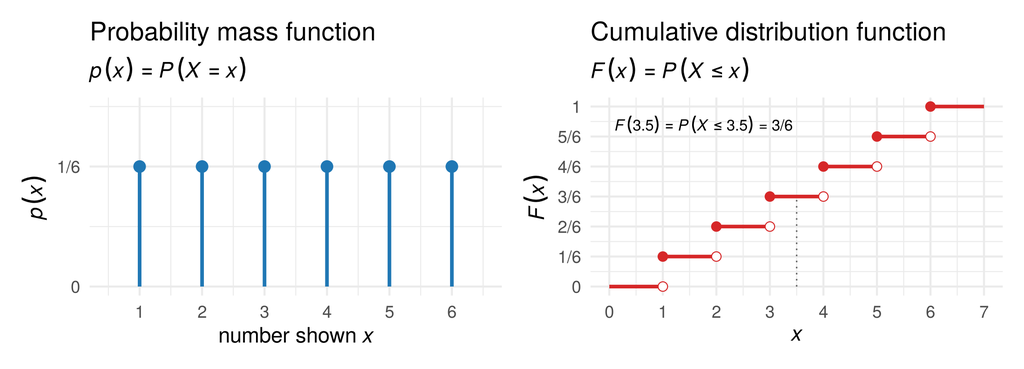

## 2 Random vectors

## Two dice: first die and sum

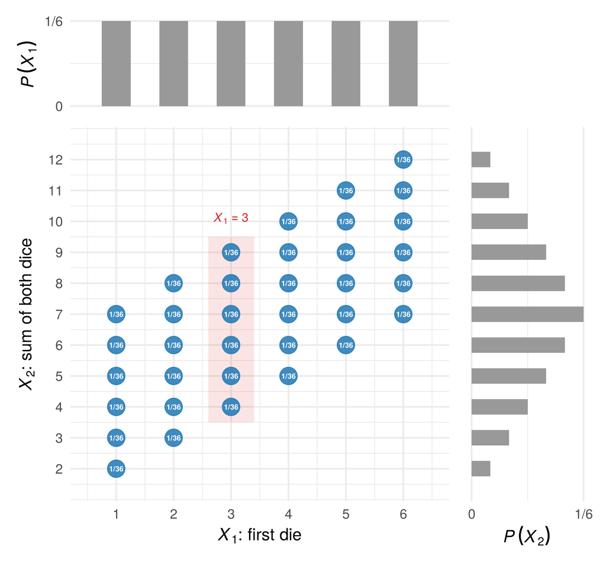

\(X_1\) = first die, \(X_2\) = sum: a **random vector** \(X=(X_1,X_2)'\).

- **Joint**: \(P(X_1=x_1,X_2=x_2)\), \(1/36\) per point
- **Marginal**: add over the other variable (grey bars)
- **Conditional**: one column, rescaled: given \(X_1=3\), the sum is \(4,\dots,9\)

## Independence

**Independent**: knowing \(X_1\) tells nothing about \(X_2\):

\[P(X_1=x_1,X_2=x_2)=P(X_1=x_1)\,P(X_2=x_2)\quad\text{for all pairs.}\]

- The **two dice** are independent: \(\frac16\cdot\frac16=\frac1{36}\).
- The **first die and the sum** are dependent: \(P(X_1=1,X_2=12)=0\), but \(P(X_1=1)P(X_2=12)>0\).

Dependence between variables is what multivariate analysis is about.

## 3 From random vectors to a data matrix

## Repeating the experiment

Repetition \(t\): random vector \(\mathbf X_t\), realisation \(\mathbf x_t\) = **row \(t\)** of \(\mathbf X\).

\[\mathbf X_1,\dots,\mathbf X_n\;\longrightarrow\;\mathbf X=\begin{pmatrix}\mathbf x_1'\\ \vdots\\ \mathbf x_n'\end{pmatrix}\]

Bold \(\mathbf X_t\): the whole repetition (a vector). Plain subscript: a variable. \(X_1\) is the first die, \(\mathbf X_1\) the first roll.

**Random sample**: rows **iid**, independent and identically distributed.

Then every \(\mathbf X_t\) has the distribution of one \(X\):

\(\mathbf X\) is \(n\) independent draws of **the same** \(X\), not one draw each of \(n\) different random vectors.

## The data come to look like the distribution

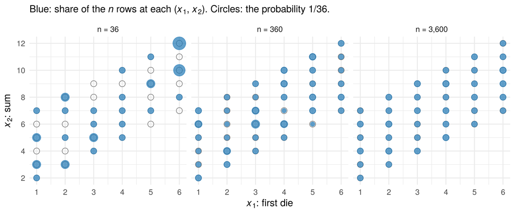

- Blue: share of the \(n\) rows at each pair. Circles: the probability \(1/36\).
- More rows, closer match: the data tell us about the unknown distribution.

## 4 Continuous random vectors

## Densities: probabilities are areas

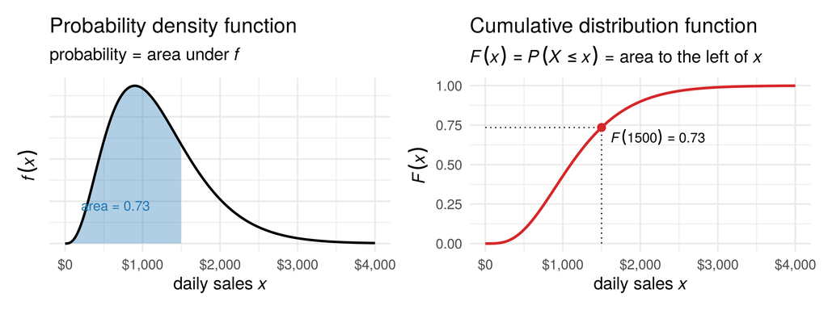

- \(P(a\le X\le b)=\int_a^b f(x)\,dx\), and \(F(x)=P(X\le x)\) is the area to the left of \(x\).
- \(f(x)\) is not a probability: it is high where values are crowded.

## The multivariate normal

[interactive chart not shown]

Flight time \(X_1\), fuel \(X_2\). Drag to rotate.

\[f(x)\propto\exp\!\Big(-\tfrac12(x-\mu)'\Sigma^{-1}(x-\mu)\Big)\]

One hill, fully described by \(\mu\) and \(\Sigma\).

## From 3D to 2D: the contour plot

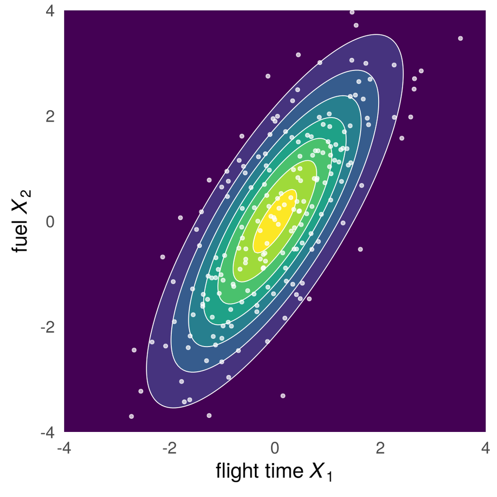

Look at the hill **from above**: lines of equal height, like a hiking map.

- Equal height = equal Mahalanobis distance \(d\).
- So every contour is an **ellipse**.

## How much probability inside each ellipse?

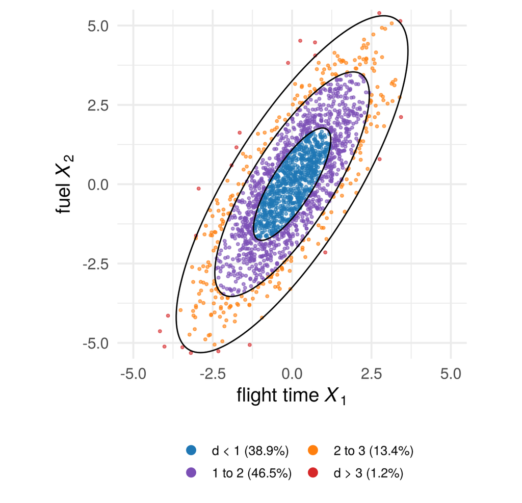

If \(X\sim N(\mu,\Sigma)\) with \(p\) variables, the squared **Mahalanobis** distance:

\[d^2=(X-\mu)'\Sigma^{-1}(X-\mu)\sim\chi^2_p\]

With \(p=2\): 39%, 86% and 98.9% within \(d=1,2,3\).

A distance is surprising if it is far in the tail of \(\chi^2_p\).

## Conditional distributions are regressions

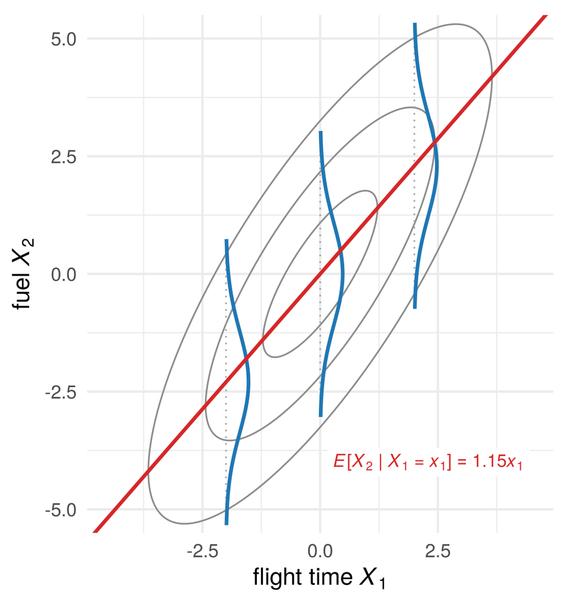

Fix flight time \(X_1=x_1\), look at fuel \(X_2\) (blue slices).

- Each slice is **normal**, all with the same spread.
- Centres on a **straight line**: \(E[X_2\mid X_1=x_1]\), the regression line.

## Correlation shapes the ellipse

[interactive chart not shown]

Standardised normal, contours \(d=1,2,3\). Move \(\rho\):

- \(\rho=0\): circles, **independent**
- \(|\rho|\to 1\): thin ellipses, almost a line

## Not every distribution is one hill

[interactive chart not shown]

Penguin bill length and depth, smoothed into a density (a **kernel density estimate**). Drag to rotate.

**Three** peaks. A normal has only one.

## The hills are the species

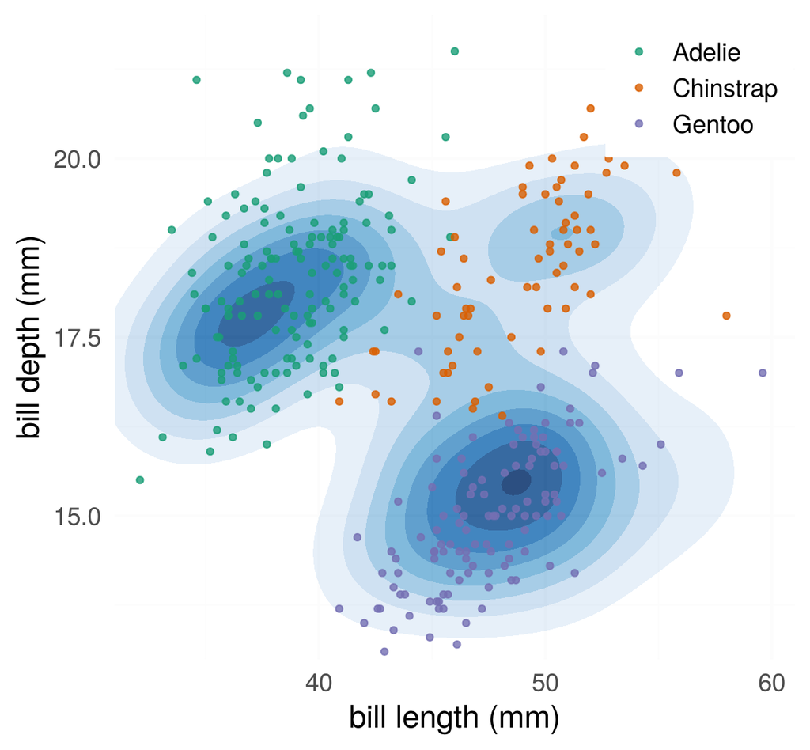

The density found the groups **without** being told the species.

Several hills suggest a mixture of groups: the idea behind cluster analysis.

## 5 Moments

## Two examples, side by side

Moments are defined the same way for every distribution; only the arithmetic differs.

|  | **Discrete**: pmf, sums | **Continuous**: pdf, integrals |
| --- | --- | --- |
| one variable | one die | daily sales |
| two variables | two dice: first die \(X_1\), sum \(X_2\) | flights: time \(X_1\), fuel \(X_2\) (normal) |

Left column: always the dice and a pmf. Right column: always a continuous variable and a pdf.

## Mean and variance

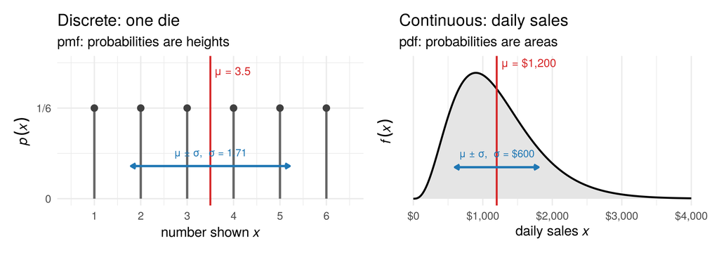

\(\mu=\sum_x x\,p(x)=3.5\) (never rolled: the **balance point**)  
\(\sigma^2=\sum_x (x-\mu)^2p(x)=35/12\)

\(\mu=\int x\,f(x)\,dx=\$1{,}200\)  
\(\sigma^2=\int (x-\mu)^2f(x)\,dx\), \(\sigma=\$600\)

## Covariance and correlation

\[\sigma_{12}=E\big[(X_1-\mu_1)(X_2-\mu_2)\big],\qquad \rho_{12}=\frac{\sigma_{12}}{\sigma_1\sigma_2}\in[-1,1]\]

**Two dice** (sum over the joint pmf)

\(\sigma_{12}=\sum\sum(x_1-\mu_1)(x_2-\mu_2)\,p(x_1,x_2)\)

Sum = first die + independent second die: \(\sigma_{12}=\operatorname{Var}(X_1)=35/12\), \(\rho_{12}=1/\sqrt2\approx0.71\)

**Flights** (integral over the joint pdf)

\(\sigma_{12}=\iint(x_1-\mu_1)(x_2-\mu_2)\,f(x_1,x_2)\)

\(\sigma_{12}=1.70\), \(\rho_{12}=0.79\): longer flights burn more fuel

## Mean vector and covariance matrix

\(\mu=E[X]\), \(\Sigma=E\big[(X-\mu)(X-\mu)'\big]\): centre (red) and shape (one-sd ellipse).

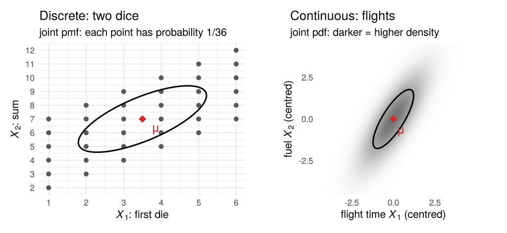

\(\mu=\begin{pmatrix}3.5\\7\end{pmatrix}\), \(\Sigma=\frac{35}{12}\begin{pmatrix}1&1\\1&2\end{pmatrix}\)

\(\mu=\begin{pmatrix}0\\0\end{pmatrix}\), \(\Sigma=\begin{pmatrix}1.48&1.70\\ 1.70&3.13\end{pmatrix}\)

For the normal (right), \(\mu\) and \(\Sigma\) describe the distribution completely; for the dice (left), they only summarise it.

## Population and sample moments

|  | Population (the distribution) | Sample (the data matrix) |
| --- | --- | --- |
| mean | \(\mu=E[X]\) | \(\bar{\mathbf x}=\frac1n\sum_t \mathbf x_t\) |
| variance | \(\sigma_j^2=E[(X_j-\mu_j)^2]\) | \(s_j^2=\frac{1}{n-1}\sum_t (x_{tj}-\bar x_j)^2\) |
| covariance matrix | \(\Sigma=E[(X-\mu)(X-\mu)']\) | \(S=\frac{1}{n-1}\sum_t (\mathbf x_t-\bar{\mathbf x})(\mathbf x_t-\bar{\mathbf x})'\) |
| correlation | \(\rho_{jk}=\sigma_{jk}/(\sigma_j\sigma_k)\) | \(r_{jk}=s_{jk}/(s_js_k)\) |

Population moments are fixed numbers. Sample moments change from sample to sample, and estimate them (Section 6).

## 6 Learning the distribution from data

## Every sample gives a different estimate

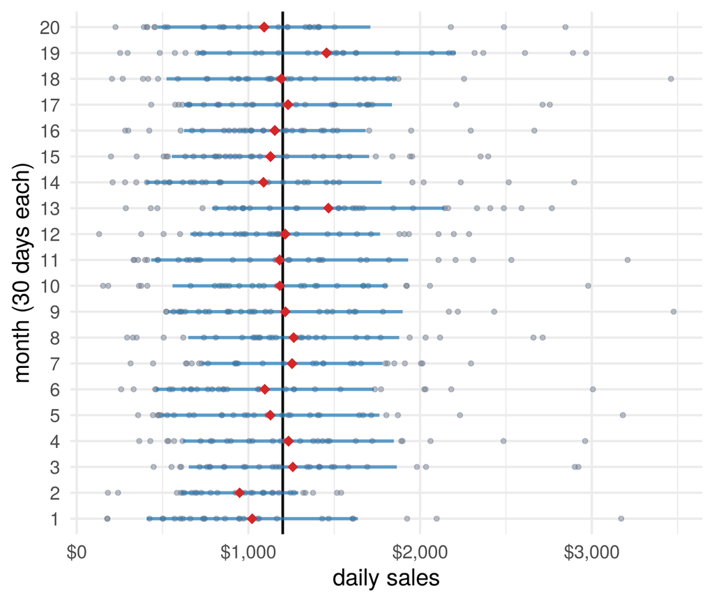

20 months of sales, 30 days each.

- ◆ sample mean \(\bar x\), — \(\bar x\pm s\)
- Black: the true \(\mu=\$1{,}200\).

\(\bar X=\frac1n\sum_t \mathbf X_t\) is itself **random**.

## Law of large numbers

[interactive chart not shown]

Rows iid draws of \(X\). Press Play.

\[\bar x=\frac1n\sum_{t=1}^n x_t\;\longrightarrow\;\mu\]

Band \(\mu\pm 2\sigma/\sqrt n\): four times the data, half the error.

Likewise \(S\to\Sigma\).

## Central limit theorem

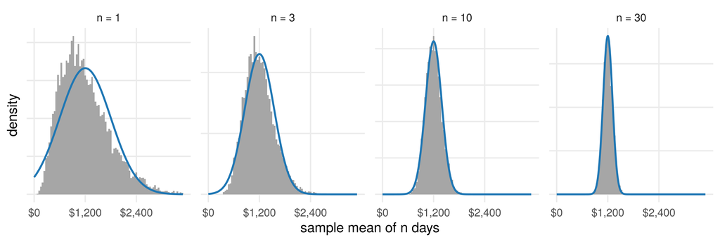

- Daily sales are **skewed** (\(n=1\)). Averages of \(n\) days become **bell-shaped**.
- For large \(n\): \(\bar X\approx N\big(\mu,\;\sigma^2/n\big)\), whatever the distribution of \(X\).

## When the rows are not identically distributed

[interactive chart not shown]

Shop A: one distribution every day (black). Shop B: growing, so \(\mathbf X_t\) depends on \(t\) (red), and there is no single curve to settle on.

## No single \(\mu\) to estimate

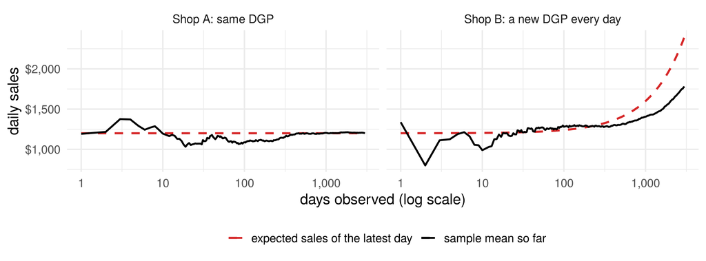

- Shop A: \(\bar x\to\mu\). Shop B: each day has its own mean \(\mu_t\).

\(\bar{\mathbf x}\) and \(S\) estimate \(\mu\) and \(\Sigma\) only if all rows share **one** distribution: the reduced form.

## Back to the states: is Alaska surprising?

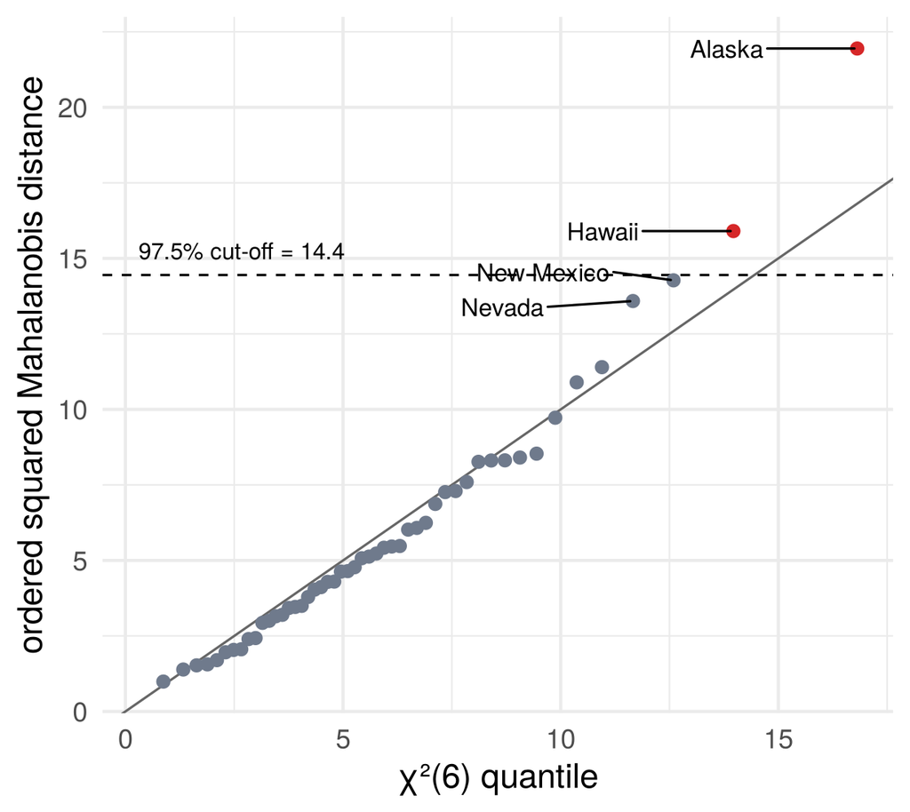

States as iid draws of one \(X\sim N(\mu,\Sigma)\). Squared **Mahalanobis** distance, with \(\bar{\mathbf x}\), \(S\) for \(\mu\), \(\Sigma\):

\[d_t^2=(\mathbf x_t-\bar{\mathbf x})'S^{-1}(\mathbf x_t-\bar{\mathbf x})\approx\chi^2_6\]

- **Q-Q plot**: sorted \(d_t^2\) against \(\chi^2_6\) quantiles; on the line if the distribution is right.
- **Alaska** and **Hawaii** exceed the 97.5% cut-off (14.4).
- Caveats: one distribution? normal? only 50 states?

## 7 From the reduced form to structural models

## Linear transformations: \(\operatorname{Var}(AX)=A\Sigma A'\)

Everything so far describes the **observed** \(X\): the **reduced form**. Structural models explain it as a linear transformation of simpler variables. If \(\operatorname{Var}(X)=\Sigma\) and \(Y=a+AX\):

\[E[Y]=a+A\mu,\qquad \operatorname{Var}(Y)=A\Sigma A'\]

**Two dice** \(D\), \(\operatorname{Var}(D)=\frac{35}{12}I\):

\[\begin{aligned}X&=\begin{pmatrix}1&0\\1&1\end{pmatrix}D\\ \operatorname{Var}(X)&=\tfrac{35}{12}\begin{pmatrix}1&1\\1&2\end{pmatrix}\end{aligned}\]

Independent dice, combined by \(A\): dependent variables.

**Flights**: shocks \(\varepsilon\), \(\operatorname{Var}(\varepsilon)=I\):

\[X=A\varepsilon,\qquad \Sigma=AA'\]

Normal shocks give normal \(X\). The structural form determines the reduced form.

## Many \(A\), one \(\Sigma\)

The structural form gives the reduced form, \(\Sigma=AA'\). Can we go back, from \(\Sigma\) to \(A\)? Not uniquely:

Any rotation \(Q=\begin{pmatrix}\cos\varphi&-\sin\varphi\\ \sin\varphi&\cos\varphi\end{pmatrix}\), \(QQ'=I\):

\[(AQ)(AQ)'=AQQ'A'=AA'=\Sigma\]

- \(\tilde\varepsilon=Q'\varepsilon\sim N(0,I)\): the **same** distribution of \(X\).
- \(\Sigma\): 3 numbers; \(A\): 4; one free angle \(\varphi\) (Introduction: turning the arrows).

Picking one \(\varphi\) needs an extra restriction: **identification** (symmetric root, Cholesky, PCA, a known coefficient).

## Coming lectures: structural models

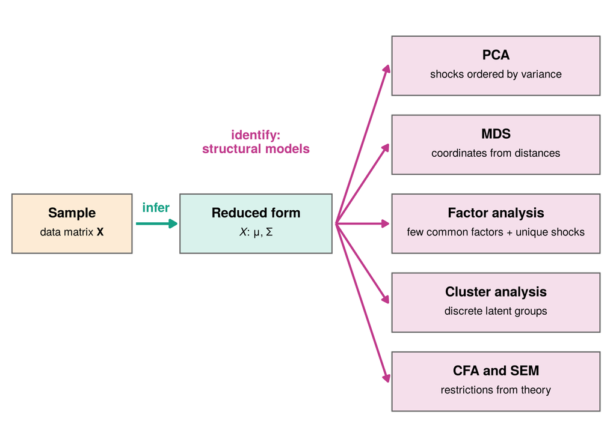

Each method maps the reduced form (\(\mu\), \(\Sigma\)) to structural parameters, with its own identifying assumptions.

Starting with **PCA**, then MDS, factor analysis, cluster analysis, CFA and SEM.

## Summary

## Takeaways

- Random variable: a number for each outcome; random vector \(X=(X_1,\dots,X_p)'\): several from one experiment.
- Rows \(\mathbf x_t\) are realisations of \(\mathbf X_t\); in a random sample, \(n\) iid draws of **one** \(X\).
- pmf (heights), pdf (areas), cdf; joint, marginal, conditional; independence.
- Multivariate normal: one hill, elliptical contours, \(d^2\sim\chi^2_p\), linear conditional means.
- Moments \(\mu\), \(\Sigma\); \(\operatorname{Var}(AX)=A\Sigma A'\).
- LLN and CLT: \(\bar{\mathbf x}\), \(S\) estimate \(\mu\), \(\Sigma\), if the rows share one distribution. Alaska and Hawaii are surprising.

All of this describes the observed \(X\). Structural models, from PCA on, try to explain it.